# Risk Factor Analysis

## Outcome Variable

**Outcome Variable:** stunted

## Predictor Variables

**Intervention Variable:** tr

**Adjustment Set:**

unadjusted

## Stratifying Variables

The analysis was stratified on these variable(s):

- anywast06
- agecat
- studyid
- country

## Data Summary

| anywast06 | agecat | studyid | country | tr | stunted | n_cell | n |
| --- | --- | --- | --- | --- | --- | --- | --- |
| 0 | 6 months | ki1017093b-PROVIDE | BANGLADESH | Control | 0 | 5 | 29 |
| 0 | 6 months | ki1017093b-PROVIDE | BANGLADESH | Control | 1 | 2 | 29 |
| 0 | 6 months | ki1017093b-PROVIDE | BANGLADESH | Other | 0 | 19 | 29 |
| 0 | 6 months | ki1017093b-PROVIDE | BANGLADESH | Other | 1 | 3 | 29 |
| 1 | 6 months | ki1017093b-PROVIDE | BANGLADESH | Control | 0 | 3 | 17 |
| 1 | 6 months | ki1017093b-PROVIDE | BANGLADESH | Control | 1 | 0 | 17 |
| 1 | 6 months | ki1017093b-PROVIDE | BANGLADESH | Other | 0 | 9 | 17 |
| 1 | 6 months | ki1017093b-PROVIDE | BANGLADESH | Other | 1 | 5 | 17 |
| 0 | 24 months | ki1017093b-PROVIDE | BANGLADESH | Other | 0 | 1 | 1 |
| 1 | 24 months | ki1017093b-PROVIDE | BANGLADESH | Other | 0 | 1 | 1 |
| 1 | 6 months | ki1066203-TanzaniaChild2 | TANZANIA, UNITED REPUBLIC OF | Control | 0 | 43 | 251 |
| 1 | 6 months | ki1066203-TanzaniaChild2 | TANZANIA, UNITED REPUBLIC OF | Control | 1 | 8 | 251 |
| 1 | 6 months | ki1066203-TanzaniaChild2 | TANZANIA, UNITED REPUBLIC OF | Other | 0 | 62 | 251 |
| 1 | 6 months | ki1066203-TanzaniaChild2 | TANZANIA, UNITED REPUBLIC OF | Other | 1 | 10 | 251 |
| 1 | 6 months | ki1066203-TanzaniaChild2 | TANZANIA, UNITED REPUBLIC OF | Zinc | 0 | 107 | 251 |
| 1 | 6 months | ki1066203-TanzaniaChild2 | TANZANIA, UNITED REPUBLIC OF | Zinc | 1 | 21 | 251 |
| 0 | 6 months | ki1066203-TanzaniaChild2 | TANZANIA, UNITED REPUBLIC OF | Control | 0 | 335 | 1456 |
| 0 | 6 months | ki1066203-TanzaniaChild2 | TANZANIA, UNITED REPUBLIC OF | Control | 1 | 39 | 1456 |
| 0 | 6 months | ki1066203-TanzaniaChild2 | TANZANIA, UNITED REPUBLIC OF | Other | 0 | 317 | 1456 |
| 0 | 6 months | ki1066203-TanzaniaChild2 | TANZANIA, UNITED REPUBLIC OF | Other | 1 | 35 | 1456 |
| 0 | 6 months | ki1066203-TanzaniaChild2 | TANZANIA, UNITED REPUBLIC OF | Zinc | 0 | 657 | 1456 |
| 0 | 6 months | ki1066203-TanzaniaChild2 | TANZANIA, UNITED REPUBLIC OF | Zinc | 1 | 73 | 1456 |
| 0 | 24 months | ki1066203-TanzaniaChild2 | TANZANIA, UNITED REPUBLIC OF | Control | 0 | 1 | 3 |
| 0 | 24 months | ki1066203-TanzaniaChild2 | TANZANIA, UNITED REPUBLIC OF | Control | 1 | 0 | 3 |
| 0 | 24 months | ki1066203-TanzaniaChild2 | TANZANIA, UNITED REPUBLIC OF | Other | 0 | 1 | 3 |
| 0 | 24 months | ki1066203-TanzaniaChild2 | TANZANIA, UNITED REPUBLIC OF | Other | 1 | 0 | 3 |
| 0 | 24 months | ki1066203-TanzaniaChild2 | TANZANIA, UNITED REPUBLIC OF | Zinc | 0 | 0 | 3 |
| 0 | 24 months | ki1066203-TanzaniaChild2 | TANZANIA, UNITED REPUBLIC OF | Zinc | 1 | 1 | 3 |
| 1 | 24 months | ki1066203-TanzaniaChild2 | TANZANIA, UNITED REPUBLIC OF | Other | 0 | 1 | 1 |
| 0 | 6 months | ki1112895-Guatemala BSC | GUATEMALA | Control | 0 | 66 | 195 |
| 0 | 6 months | ki1112895-Guatemala BSC | GUATEMALA | Control | 1 | 31 | 195 |
| 0 | 6 months | ki1112895-Guatemala BSC | GUATEMALA | Other | 0 | 71 | 195 |
| 0 | 6 months | ki1112895-Guatemala BSC | GUATEMALA | Other | 1 | 27 | 195 |
| 1 | 6 months | ki1112895-Guatemala BSC | GUATEMALA | Control | 0 | 0 | 6 |
| 1 | 6 months | ki1112895-Guatemala BSC | GUATEMALA | Control | 1 | 2 | 6 |
| 1 | 6 months | ki1112895-Guatemala BSC | GUATEMALA | Other | 0 | 2 | 6 |
| 1 | 6 months | ki1112895-Guatemala BSC | GUATEMALA | Other | 1 | 2 | 6 |

The following strata were considered:

- anywast06: 0, agecat: 24 months, studyid: ki1017093b-PROVIDE, country: BANGLADESH
- anywast06: 0, agecat: 24 months, studyid: ki1066203-TanzaniaChild2, country: TANZANIA, UNITED REPUBLIC OF
- anywast06: 0, agecat: 6 months, studyid: ki1017093b-PROVIDE, country: BANGLADESH
- anywast06: 0, agecat: 6 months, studyid: ki1066203-TanzaniaChild2, country: TANZANIA, UNITED REPUBLIC OF
- anywast06: 0, agecat: 6 months, studyid: ki1112895-Guatemala BSC, country: GUATEMALA
- anywast06: 1, agecat: 24 months, studyid: ki1017093b-PROVIDE, country: BANGLADESH
- anywast06: 1, agecat: 24 months, studyid: ki1066203-TanzaniaChild2, country: TANZANIA, UNITED REPUBLIC OF
- anywast06: 1, agecat: 6 months, studyid: ki1017093b-PROVIDE, country: BANGLADESH
- anywast06: 1, agecat: 6 months, studyid: ki1066203-TanzaniaChild2, country: TANZANIA, UNITED REPUBLIC OF
- anywast06: 1, agecat: 6 months, studyid: ki1112895-Guatemala BSC, country: GUATEMALA

### Dropped Strata

Some strata were dropped due to rare outcomes:

- anywast06: 0, agecat: 6 months, studyid: ki1017093b-PROVIDE, country: BANGLADESH
- anywast06: 1, agecat: 6 months, studyid: ki1017093b-PROVIDE, country: BANGLADESH
- anywast06: 0, agecat: 24 months, studyid: ki1017093b-PROVIDE, country: BANGLADESH
- anywast06: 1, agecat: 24 months, studyid: ki1017093b-PROVIDE, country: BANGLADESH
- anywast06: 0, agecat: 24 months, studyid: ki1066203-TanzaniaChild2, country: TANZANIA, UNITED REPUBLIC OF
- anywast06: 1, agecat: 24 months, studyid: ki1066203-TanzaniaChild2, country: TANZANIA, UNITED REPUBLIC OF
- anywast06: 1, agecat: 6 months, studyid: ki1112895-Guatemala BSC, country: GUATEMALA

## Methods Detail

We’re interested in the causal parameters $E[Y_a]$ for all values of $a \in \mathcal{A}$. These parameters represent the mean outcome if, possibly contrary to fact, we intervened to set all units to have $A=a$. Under the randomization and positivity assumptions, these are identified by the statistical parameters $\psi_a=E_W[E_{Y|A,W}(Y|A=a,W)]$. In addition, we’re interested in the mean of $Y$, $E[Y]$ under no intervention (the observed mean). We will estimate these parameters by using SuperLearner to fit the relevant likelihood factors – $E_{Y|A,W}(Y|A=a,W)$ and $p(A=a|W)$, and then updating our likelihood fit using a joint TMLE.

For unadjusted analyses ($W=\{\}$), initial likelihoods were estimated using Lrnr_glm to estimate the simple $E(Y|A)$ and Lrnr_mean to estimate $p(A)$. For adjusted analyses, a small library containing Lrnr_glmnet, Lrnr_xgboost, and Lrnr_mean was used.

Having estimated these parameters, we will then use the delta method to estimate relative risks and attributable risks relative to a prespecified baseline level of $A$.

# Results Detail

## Results Plots

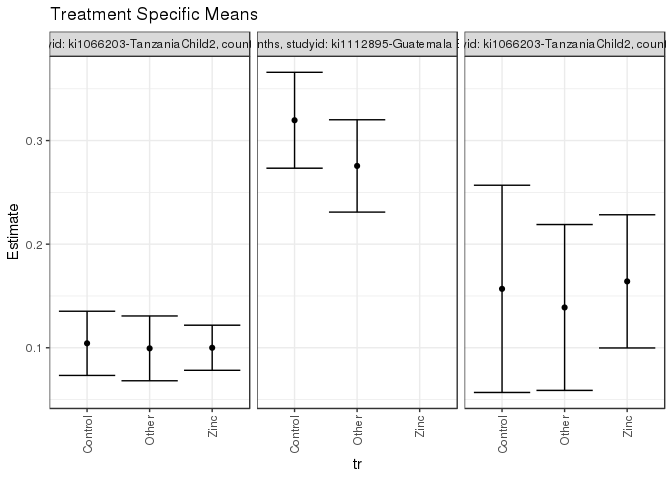

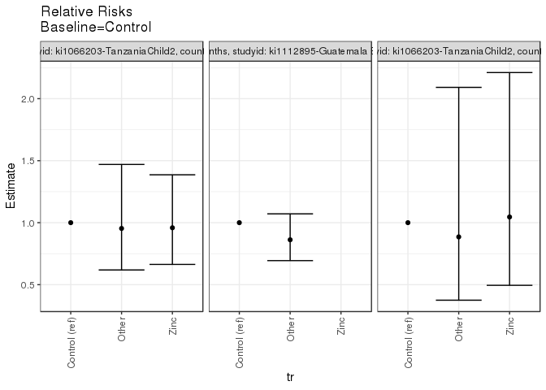

[figure not shown]

[figure not shown]

## Results Table

### Parameter: TSM

| anywast06 | agecat | studyid | country | intervention_level | baseline_level | estimate | ci_lower | ci_upper |
| --- | --- | --- | --- | --- | --- | --- | --- | --- |
| 0 | 6 months | ki1066203-TanzaniaChild2 | TANZANIA, UNITED REPUBLIC OF | Control | NA | 0.1042781 | 0.0732936 | 0.1352626 |
| 0 | 6 months | ki1066203-TanzaniaChild2 | TANZANIA, UNITED REPUBLIC OF | Other | NA | 0.0994318 | 0.0681604 | 0.1307032 |
| 0 | 6 months | ki1066203-TanzaniaChild2 | TANZANIA, UNITED REPUBLIC OF | Zinc | NA | 0.1000000 | 0.0782301 | 0.1217699 |
| 0 | 6 months | ki1112895-Guatemala BSC | GUATEMALA | Control | NA | 0.3195876 | 0.2733073 | 0.3658680 |
| 0 | 6 months | ki1112895-Guatemala BSC | GUATEMALA | Other | NA | 0.2755102 | 0.2309417 | 0.3200787 |
| 1 | 6 months | ki1066203-TanzaniaChild2 | TANZANIA, UNITED REPUBLIC OF | Control | NA | 0.1568627 | 0.0568538 | 0.2568717 |
| 1 | 6 months | ki1066203-TanzaniaChild2 | TANZANIA, UNITED REPUBLIC OF | Other | NA | 0.1388889 | 0.0588480 | 0.2189298 |
| 1 | 6 months | ki1066203-TanzaniaChild2 | TANZANIA, UNITED REPUBLIC OF | Zinc | NA | 0.1640625 | 0.0997787 | 0.2283463 |

### Parameter: E(Y)

| anywast06 | agecat | studyid | country | intervention_level | baseline_level | estimate | ci_lower | ci_upper |
| --- | --- | --- | --- | --- | --- | --- | --- | --- |
| 0 | 6 months | ki1066203-TanzaniaChild2 | TANZANIA, UNITED REPUBLIC OF | NA | NA | 0.1009615 | 0.0854811 | 0.1164420 |
| 0 | 6 months | ki1112895-Guatemala BSC | GUATEMALA | NA | NA | 0.2974359 | 0.2331098 | 0.3617619 |
| 1 | 6 months | ki1066203-TanzaniaChild2 | TANZANIA, UNITED REPUBLIC OF | NA | NA | 0.1553785 | 0.1104725 | 0.2002845 |

### Parameter: RR

| anywast06 | agecat | studyid | country | intervention_level | baseline_level | estimate | ci_lower | ci_upper |
| --- | --- | --- | --- | --- | --- | --- | --- | --- |
| 0 | 6 months | ki1066203-TanzaniaChild2 | TANZANIA, UNITED REPUBLIC OF | Control | Control | 1.0000000 | 1.0000000 | 1.000000 |
| 0 | 6 months | ki1066203-TanzaniaChild2 | TANZANIA, UNITED REPUBLIC OF | Other | Control | 0.9535257 | 0.6186263 | 1.469726 |
| 0 | 6 months | ki1066203-TanzaniaChild2 | TANZANIA, UNITED REPUBLIC OF | Zinc | Control | 0.9589744 | 0.6634908 | 1.386051 |
| 0 | 6 months | ki1112895-Guatemala BSC | GUATEMALA | Control | Control | 1.0000000 | 1.0000000 | 1.000000 |
| 0 | 6 months | ki1112895-Guatemala BSC | GUATEMALA | Other | Control | 0.8620803 | 0.6938338 | 1.071125 |
| 1 | 6 months | ki1066203-TanzaniaChild2 | TANZANIA, UNITED REPUBLIC OF | Control | Control | 1.0000000 | 1.0000000 | 1.000000 |
| 1 | 6 months | ki1066203-TanzaniaChild2 | TANZANIA, UNITED REPUBLIC OF | Other | Control | 0.8854167 | 0.3748939 | 2.091159 |
| 1 | 6 months | ki1066203-TanzaniaChild2 | TANZANIA, UNITED REPUBLIC OF | Zinc | Control | 1.0458984 | 0.4948705 | 2.210485 |

### Parameter: PAR

| anywast06 | agecat | studyid | country | intervention_level | baseline_level | estimate | ci_lower | ci_upper |
| --- | --- | --- | --- | --- | --- | --- | --- | --- |
| 0 | 6 months | ki1066203-TanzaniaChild2 | TANZANIA, UNITED REPUBLIC OF | Control | NA | -0.0033165 | -0.0298962 | 0.0232631 |
| 0 | 6 months | ki1112895-Guatemala BSC | GUATEMALA | Control | NA | -0.0221517 | -0.0668280 | 0.0225245 |
| 1 | 6 months | ki1066203-TanzaniaChild2 | TANZANIA, UNITED REPUBLIC OF | Control | NA | -0.0014843 | -0.0906687 | 0.0877002 |

### Parameter: PAF

| anywast06 | agecat | studyid | country | intervention_level | baseline_level | estimate | ci_lower | ci_upper |
| --- | --- | --- | --- | --- | --- | --- | --- | --- |
| 0 | 6 months | ki1066203-TanzaniaChild2 | TANZANIA, UNITED REPUBLIC OF | Control | NA | -0.0328495 | -0.3326608 | 0.1995127 |
| 0 | 6 months | ki1112895-Guatemala BSC | GUATEMALA | Control | NA | -0.0744756 | -0.2491010 | 0.0757370 |
| 1 | 6 months | ki1066203-TanzaniaChild2 | TANZANIA, UNITED REPUBLIC OF | Control | NA | -0.0095525 | -0.7825663 | 0.4282421 |